# Cars Analysis and Modeling

## Data Cleaning

To clean the dataset it was vital to open the csv file and investigate the types of attributes and samples that were given. To get a quick glance of the data we first open the csv file as follows:

```r
cars <- read_csv("cars.csv")
head(cars, 20)
```

```
## # A tibble: 20 x 30
##    manufacturer_na~ model_name transmission color odometer_value year_produced
##    <chr>            <chr>      <chr>        <chr>          <dbl>         <dbl>
##  1 Subaru           Outback    automatic    silv~         190000          2010
##  2 Subaru           Outback    automatic    blue          290000          2002
##  3 Subaru           Forester   automatic    red           402000          2001
##  4 Subaru           Impreza    mechanical   blue           10000          1999
##  5 Subaru           Legacy     automatic    black         280000          2001
##  6 Subaru           Outback    automatic    silv~         132449          2011
##  7 Subaru           Forester   automatic    black         318280          1998
##  8 Subaru           Legacy     automatic    silv~         350000          2004
##  9 Subaru           Outback    automatic    grey          179000          2010
## 10 Subaru           Forester   automatic    silv~         571317          1999
## 11 Subaru           Forester   mechanical   other         280000          2003
## 12 Subaru           Tribeca    automatic    grey          256000          2008
## 13 Subaru           Forester   mechanical   other         321000          2002
## 14 Subaru           Justy      mechanical   red            49999          2001
## 15 Subaru           Outback    automatic    brown         154685          2011
## 16 Subaru           Outback    automatic    black         163219          2004
## 17 Subaru           Outback    automatic    other         318650          2005
## 18 Subaru           Impreza    mechanical   blue          191000          2005
## 19 Subaru           Forester   automatic    silv~         179000          2014
## 20 Subaru           Forester   automatic    black         159000          2013
## # ... with 24 more variables: engine_fuel <chr>, engine_has_gas <lgl>,
## #   engine_type <chr>, engine_capacity <dbl>, body_type <chr>,
## #   has_warranty <lgl>, state <chr>, drivetrain <chr>, price_usd <dbl>,
## #   is_exchangeable <lgl>, location_region <chr>, number_of_photos <dbl>,
## #   up_counter <dbl>, feature_0 <lgl>, feature_1 <lgl>, feature_2 <lgl>,
## #   feature_3 <lgl>, feature_4 <lgl>, feature_5 <lgl>, feature_6 <lgl>,
## #   feature_7 <lgl>, feature_8 <lgl>, feature_9 <lgl>, duration_listed <dbl>
```

Afterwords, it was crucial to obtain a quick summary of our dataset in order to investigate the steps needed to clean the dataset. This was done with the following line of code:

```r
summary(cars)
```

```
##  manufacturer_name   model_name        transmission          color
##  Length:38531       Length:38531       Length:38531       Length:38531
##  Class :character   Class :character   Class :character   Class :character
##  Mode  :character   Mode  :character   Mode  :character   Mode  :character
##
##
##
##
##  odometer_value    year_produced  engine_fuel        engine_has_gas
##  Min.   :      0   Min.   :1942   Length:38531       Mode :logical
##  1st Qu.: 158000   1st Qu.:1998   Class :character   FALSE:37184
##  Median : 250000   Median :2003   Mode  :character   TRUE :1347
##  Mean   : 248865   Mean   :2003
##  3rd Qu.: 325000   3rd Qu.:2009
##  Max.   :1000000   Max.   :2019
##
##  engine_type        engine_capacity  body_type         has_warranty
##  Length:38531       Min.   :0.200   Length:38531       Mode :logical
##  Class :character   1st Qu.:1.600   Class :character   FALSE:38082
##  Mode  :character   Median :2.000   Mode  :character   TRUE :449
##                     Mean   :2.055
##                     3rd Qu.:2.300
##                     Max.   :8.000
##                     NA's   :10
##     state            drivetrain          price_usd     is_exchangeable
##  Length:38531       Length:38531       Min.   :    1   Mode :logical
##  Class :character   Class :character   1st Qu.: 2100   FALSE:24945
##  Mode  :character   Mode  :character   Median : 4800   TRUE :13586
##                                        Mean   : 6640
##                                        3rd Qu.: 8990
##                                        Max.   :50000
##
##  location_region    number_of_photos   up_counter      feature_0
##  Length:38531       Min.   : 1.000   Min.   :   1.00   Mode :logical
##  Class :character   1st Qu.: 5.000   1st Qu.:   2.00   FALSE:29725
##  Mode  :character   Median : 8.000   Median :   5.00   TRUE :8806
##                     Mean   : 9.649   Mean   :  16.31
##                     3rd Qu.:12.000   3rd Qu.:  16.00
##                     Max.   :86.000   Max.   :1861.00
##
```

[output cut: 9 more lines]

```
##  Mode :logical   Mode :logical   Mode :logical   Mode :logical
##  FALSE:24811     FALSE:31943     FALSE:28369     FALSE:22528
##  TRUE :13720     TRUE :6588      TRUE :10162     TRUE :16003
##
##
##
##
##  feature_9       duration_listed
##  Mode :logical   Min.   :   0.00
##  FALSE:16206     1st Qu.:  23.00
##  TRUE :22325     Median :  59.00
##                  Mean   :  80.58
##                  3rd Qu.:  91.00
##                  Max.   :2232.00
##
```

From the summary we clearly see that engine_has_gas, has_warranty, and state have very little variability and for that reason they will be removed from the dataset. Furthermore, upon researching the features attribute it was uncovered that the data had severe inconsistencies(according to the creator) and for that reason will be removed. Therefore, we run the select command in order to remove these attributes.

```r
cars_edited <- dplyr::select(cars, -8 & -(12:13) & -(20:29))
head(cars_edited, 20)
```

```
## # A tibble: 20 x 17
##    manufacturer_na~ model_name transmission color odometer_value year_produced
##    <chr>            <chr>      <chr>        <chr>          <dbl>         <dbl>
##  1 Subaru           Outback    automatic    silv~         190000          2010
##  2 Subaru           Outback    automatic    blue          290000          2002
##  3 Subaru           Forester   automatic    red           402000          2001
##  4 Subaru           Impreza    mechanical   blue           10000          1999
##  5 Subaru           Legacy     automatic    black         280000          2001
##  6 Subaru           Outback    automatic    silv~         132449          2011
##  7 Subaru           Forester   automatic    black         318280          1998
##  8 Subaru           Legacy     automatic    silv~         350000          2004
##  9 Subaru           Outback    automatic    grey          179000          2010
## 10 Subaru           Forester   automatic    silv~         571317          1999
## 11 Subaru           Forester   mechanical   other         280000          2003
## 12 Subaru           Tribeca    automatic    grey          256000          2008
## 13 Subaru           Forester   mechanical   other         321000          2002
## 14 Subaru           Justy      mechanical   red            49999          2001
## 15 Subaru           Outback    automatic    brown         154685          2011
## 16 Subaru           Outback    automatic    black         163219          2004
## 17 Subaru           Outback    automatic    other         318650          2005
## 18 Subaru           Impreza    mechanical   blue          191000          2005
## 19 Subaru           Forester   automatic    silv~         179000          2014
## 20 Subaru           Forester   automatic    black         159000          2013
## # ... with 11 more variables: engine_fuel <chr>, engine_type <chr>,
## #   engine_capacity <dbl>, body_type <chr>, drivetrain <chr>, price_usd <dbl>,
## #   is_exchangeable <lgl>, location_region <chr>, number_of_photos <dbl>,
## #   up_counter <dbl>, duration_listed <dbl>
```

Now to proceed with cleaning and analyzation we need a more robust knowledge of our dataset. For this reason it is vital to understand the type of data for each attribute. Therefore, we must create a table to organize all our attributes.

| Column | Details | Value/(Units) | Data Type |
| --- | --- | --- | --- |
| A | Manufacturer Name | Name of vehicle manufacturer | Nominal |
| B | Model Name | Name of vehicle model | Nominal |
| C | Transmission | Type of the transmission | Nominal |
| D | Color | Vehicle body color | Nominal |
| E | Odometer Value | Vehicle odometer value in km | Continuous |
| F | Year Produced | The year the car was produced | Continuous |
| G | Engine Fuel | Fuel type of the engine | Nominal |
| I | Engine Type | Vehicle engine type | Nominal |
| J | Engine Capacity | The capacity of the engine in liters | Nominal |
| K | Body Type | Type of the body (hatchback, sedan, etc.) | Nominal |
| M | Drivetrain | Front/rear/all drivetrain | Nominal |
| N | Price USD | Price of a cars as listed in the catalog in USD | Continuous |
| O | Exchangeable | If True the owner of the car is ready to exchange this car to other cars with little or no additional payment | Nominal |
| P | Location Region | The region in Belarus where the car is listed for sale | Nominal |
| Q | Number of Photos | Number of photos the cas has | Continous |
| R | Up Counter | How many times the sample has been upped in the catalog to raise its position | Continuous |
| S | Duration Listed | Number of days the car is listed in the catalog | Continuous |

From summary we notice that there exists 10 NA’s in the attribute engine-capacity. Our understanding of vehicles informs us that engine-capacity is a categorical data-type and as such NA is crucial to our understanding of the data. The NA values serve as a distinguishment for the Electric Vehicles in the data. For the sake of future analyzation is will serve great use to replace our NA values with an arbitrary number. For our sake we choose to change NA values to 999. Thus we do the following:

```r
summary(cars_edited$engine_capacity)
```

```
##    Min. 1st Qu.  Median    Mean 3rd Qu.    Max.    NA's
##   0.200   1.600   2.000   2.055   2.300   8.000      10
```

```r
cars_edited <- cars_edited %>% mutate(engine_capacity = coalesce(engine_capacity, 999))
summary(cars_edited$engine_capacity)
```

```
##    Min. 1st Qu.  Median    Mean 3rd Qu.    Max.
##   0.200   1.600   2.000   2.314   2.300 999.000
```

Once the unnecessary attributes were filtered and the NA’s were accounted for it was of incredible importance to investigate for duplicate samples. The code for doing this procedure was as follows:

```r
count(cars_edited)
```

```
## # A tibble: 1 x 1
##       n
##   <int>
## 1 38531
```

```r
sum(duplicated(cars_edited))
```

```
## [1] 41
```

```r
which(duplicated(cars_edited))
```

```
##  [1]  5768  6557  9997 11381 11705 12811 17339 18185 27961 31994 32018 32019
## [13] 32023 32026 32029 32035 32037 32054 32127 32129 32180 32181 32296 32297
## [25] 32299 32300 32302 32303 32305 32307 32308 32309 32311 32313 32314 32316
## [37] 32317 32318 32319 32322 32326
```

```r
cars_edited <- cars_edited %>% distinct()
count(cars_edited)
```

```
## # A tibble: 1 x 1
##       n
##   <int>
## 1 38490
```

Duplicate entries were identified and removed from the dataset. 41 such duplicate entries existed.

## Dataset Training and Testing

For the purpose of effectively analyzing the real-world performance of the models that will be used to solve the question we split the dataset into a “Training” dataset and a “Testing dataset. The”Training" set comprised of a random selection of 80% of our dataset and the “Testing” was the rest of the samples not included in the “Training” dataset(20%). The reason for the split was the necessity to be able to access how accurately the models were able to predict the price of a vehicle given a seperate portion of samples in the dataset. By testing our models against data not in our training set we can effectively see how well the model holds up with the addition of new vehicles we wish to predict. This was done as following:

```r
set.seed(123)
training.samples <- cars_edited$manufacturer_name %>% createDataPartition(p = 0.8, list = FALSE)
train.data <- cars_edited[training.samples,]
test.data <- cars_edited[-training.samples,]
```

# Data Analysis and Modeling:

## Visualizations used to analyze data

In an attempt to gain a robust knowledge of our dataset several visualizations were used. Visualization of our data was done in two sections. Initially each attribute was graphed in order to gain a general understanding of how the samples are distributed for each attribute. This was done with the help of Bar Graphs, Histograms, Boxplots, and the count function. Once a general understanding of each attribute was gained we began to visualize various combinations of attributions. These visualizations were vital in seeing different relationships among our samples. The visualizations that were used were Balloon Plot, Scatterplot, frequency polygons, dplyr::summarize, and Boxplots.

Different ML methods that we used in the Goal:

Multiple Linear Regression: This was used for the sake of gauging the impact of the continuous attributes on the price of the vehicle. This model is simple to understand and involves less computing power than more advance models which led to our decision to utilize this ML method as our first model.

SVR: Used to see if there is a model that can handle every attribute and adjust the model according to its impact on price. Although this model involves much more computing power we believed that the robust nature of this model lends itself to a high level of accuracy. This models effectiveness with categorical data, and ability to work with both linear and non-linear boundaries makes it a prime model for our dataset. Furthermore, in order to optimize our SVR model we will use linear, polynomial, and radial kernel transformations and compare the results from the models that we generate.

Decision Tree (Partition): Used for predictive modeling. Since it is incredibly robust and relies on very few assumptions we believed it would be able to handle possible outliers in our data and work around the size of our dataset to produce an optimal model. Its simpler nature also makes it a model that would be preferred over other models(such as Random Forest Regression or KNN).

Random Forest Regression: Albeit, Random Forest Regression is more complicated than a Decision Tree since it leverages multiple decision trees it is still a crucial model for our dataset. The reason for using this model is for the sake of seeing if we can create an even more accurate model. If we find the accuracy is marginally better it may be preferred to use a Decision Tree since its easier to compute. Nevertheless, the Random Forest Regression is a wonderful tool in creating a predictive model and worth testing out for the sake of optimization.

KNN:K Nearest Neighbor was chosen due to its popularity and simplicity. KNN is able to handle our Categorical as well as Continuous attributes and for that reason it is a good model to be used to predict price. It will be vital to compare this model with the other models to investigate how useful of a model it is for our dataset.

### PHASE 2 PART: Describe the different ways you tried to answer the questions and goals

## How did you reach your conclusions?

What graphs we chose to solve our questions and why Our answers to our questions based on the graphs

Q: What impact does a region have on price?

Graphs used: Pie chart How these graphs helped us solve the problem: This graph helped solve the problem by giving a percentage of the cars that were sold in a region, by the mean price. It was easy to see which regions had the biggest impact on price thanks to this graph.

Q: What is the distribution of manufacturers and whether manufacturers have a significant impact on the asking price of a vehicle?

Graphs used: Bar graph How these graphs helped us solve the problem: A bar graph for this question was helpful because each manufacturer had it’s own bar, and the highest bar represents the highest asking price of a vehicle. We were able to answer our question thanks to this graph.

Q: What is the relationship between odometer and price?

Graphs used: Scatter plot How these graphs helped us solve the problem: This graph helped solve the problem by allowing us to graph a line of best fit to the data, and by doing so seeing the relationship between the data.

Q: Does the number of photos a vehicle has impact the selling price?

Graphs used: Scatter plot How these graphs helped us solve the problem: This graph helped us solve the problem by allowing us to see the relationship between the two variables by doing a line of best fit.

Q: Does the number of times a vehicle has been upped in the catalog to raise its position impact the selling price?

Graphs used: Scatter plot How these graphs helped us solve the problem: Using a scatter plot for this question again allowed us to see the relationship between the two variables. With that we can come up with a solution to the question.

Q: Relationship between Engine Type and Body Type? What is the impact of Engine Type and Body Type on the selling price?

Graphs used: Mosaic How these graphs helped us solve the problem: This graph helped us solve the problem by giving us a colored graph that showed the amount of cars with a specific body type and engine. We were able to confirm the acuracy of the graph and come to a conclusion.

Q: What is the most popular model and whether we can conclude that the popularity of a model has a direct impact on the price of a vehicle?

Q: What is the average age of each vehicle manufacturer and whether the manufacturer changes how the production year impacts the selling price?

Graphs used: Scatter plot How these graphs helped us solve the problem: The use of a scatter plot here is profound. It was VERY clear of an answer, just by a quick inspection of the graph there was a clear answer.

# Final outcomes and Analysis

```r
LMCont <- lm(price_usd ~ odometer_value
             + year_produced
             + number_of_photos
             + duration_listed
             + up_counter
             , data = train.data)

step.LMConts <- LMCont %>% stepAIC(trace = FALSE)
```

Now that the model is created it is vital to check the accuracy of the model. To do this we will utilize our test.data to test how accurately the Linear Regression model can predicted the price of a vehicle.

```r
LMContPrediction <- predict(step.LMConts, test.data)
rmse(test.data$price_usd, LMContPrediction)
```

```
## [1] 4573.511
```

```r
R2(LMContPrediction,test.data$price_usd)
```

```
## [1] 0.5095891
```

## What are the answers for the proposed questions?

Q: What is the distribution of manufacturers and whether manufacturers have a significant impact on the asking price of a vehicle?

A: We can confirm that there is a relationship between the manufacturer and asking price.

Q: What is the relationship between odometer and price?

A: The higher the odometer the lower the price is for the vehicle.

Q: Does the number of photos a vehicle has impact the selling price?

A: Yes, the more photos a vehicle has, the higher the selling price.

Q: Does the number of times a vehicle has been upped in the catalog to raise its position impact the selling price?

A: Yes, the number of times a vehicle has been upped raises the selling price

Q: What is the most popular model and whether we can conclude that the popularity of a model has a direct impact on the price of a vehicle?

A:The popularity of a vehicle does seem to have an impact on the average_price of a vehicle.

Q: What is the average age of each vehicle manufacturer and whether the manufacturer changes how the production year impacts the selling price?

A: The manufacturer does change how the production year affects the selling price.

## What are the justifications for your answers?

How the analysis of the graphs lead to the answer:

**Q:** What impact does a region have on price?

**Justification:** To answer this question we decided to use a pie chart so we can see the average prices per region in comparison with each other.

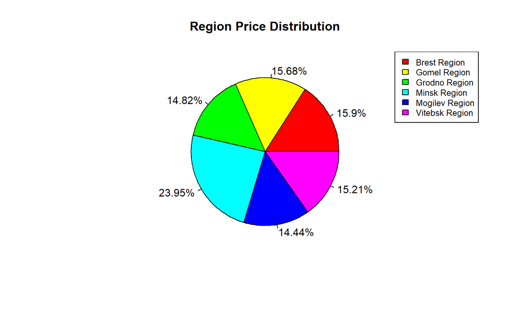

```r
group_by(regionPriceDF, regionPriceDF$location_region) %>%
  summarise(
    count = n(),
    mean = mean(price_usd, na.rm = TRUE),
    sd = sd(price_usd, na.rm = TRUE)
  )
```

```
## # A tibble: 6 x 4
##   `regionPriceDF$location_region` count  mean    sd
## * <chr>                           <int> <dbl> <dbl>
## 1 Brest Region                     2989 5091. 4652.
## 2 Gomel Region                     3140 5022. 4603.
## 3 Grodno Region                    2485 4745. 4223.
## 4 Minsk Region                    24193 7668. 7117.
## 5 Mogilev Region                   2678 4622. 4654.
## 6 Vitebsk Region                   3005 4870. 4450.
```

**Q:** What is the distribution of manufacturers and whether manufacturers have a significant impact on the asking price of a vehicle?

**Justification:** To Tackle the question to this problem we decided to use a bar graph, since we have categorical data and continuous data.

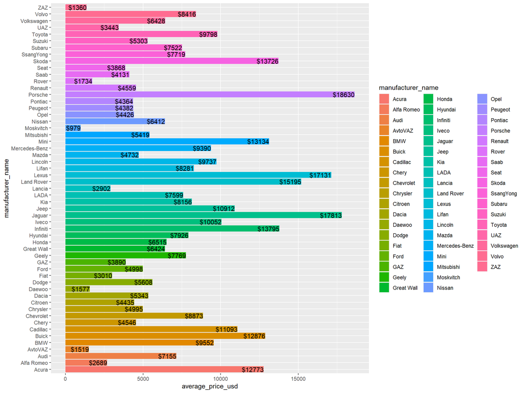

```r
manuPriceDF <- group_by(cars_edited, manufacturer_name)
manuPriceDF_averages <- summarise(manuPriceDF, average_price_usd = mean(price_usd))
View(manuPriceDF_averages)
ggplot(manuPriceDF_averages, aes(x = average_price_usd, y = manufacturer_name)) + geom_bar(aes(fill = manufacturer_name),stat="identity") + geom_text(aes(label =  paste0("$",round(average_price_usd)), hjust = 1))
```

Looking at the bar graph we can make an assumption of the data, and that assumption seems is that the manufacturer of a vehicle has an impact on asking price. Again though we can’t assume it’s correct, we need to confirm this with a one-way anova test.

```r
manuSumm <- group_by(manuPriceDF, manuPriceDF$manufacturer_name) %>%
  summarise(
    count = n(),
    mean = mean(price_usd, na.rm = TRUE),
    sd = sd(price_usd, na.rm = TRUE)
  )

# Compute the analysis of variance
res.aovTwo <- aov(manuPriceDF$price_usd ~ manuPriceDF$manufacturer_name,
                  data = manuPriceDF)

summary(res.aovTwo)
```

```
##                                  Df    Sum Sq   Mean Sq F value Pr(>F)
## manuPriceDF$manufacturer_name    54 2.917e+11 5.402e+09   160.1 <2e-16 ***
## Residuals                     38435 1.297e+12 3.374e+07
## ---
## Signif. codes:  0 '***' 0.001 '**' 0.01 '*' 0.05 '.' 0.1 ' ' 1
```

With the results **we can confirm that there is a relationship between the manufacturer and asking price.**

**Q:** What is the relationship between odometer and price?

**Justification:** When we investigate this graph we initially notice that the line of best fit seems to be going down as the odometer value increases.

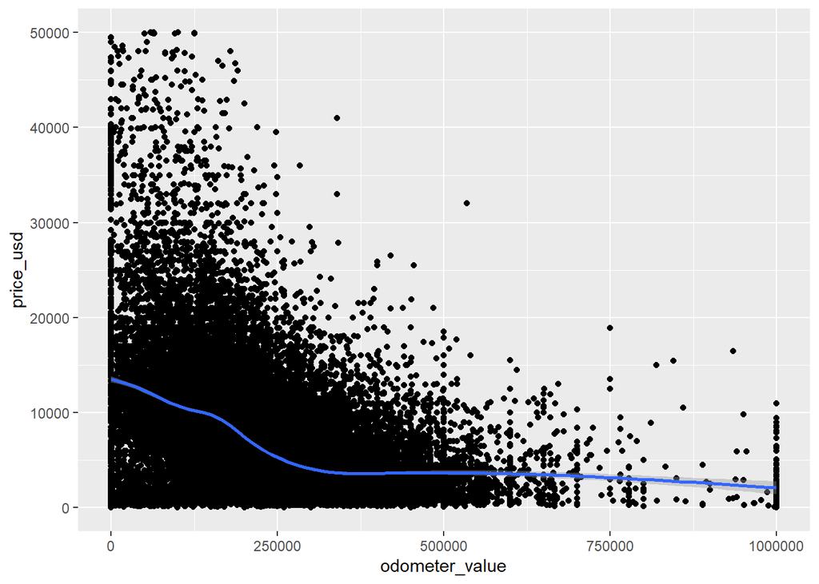

However, this doesn’t justify that the higher the odometer the lower the price is for the vehicle. In order to show this we will use linear regression, and check the percentage of accuracy of that line. Using this we will come up with an answer to our question.

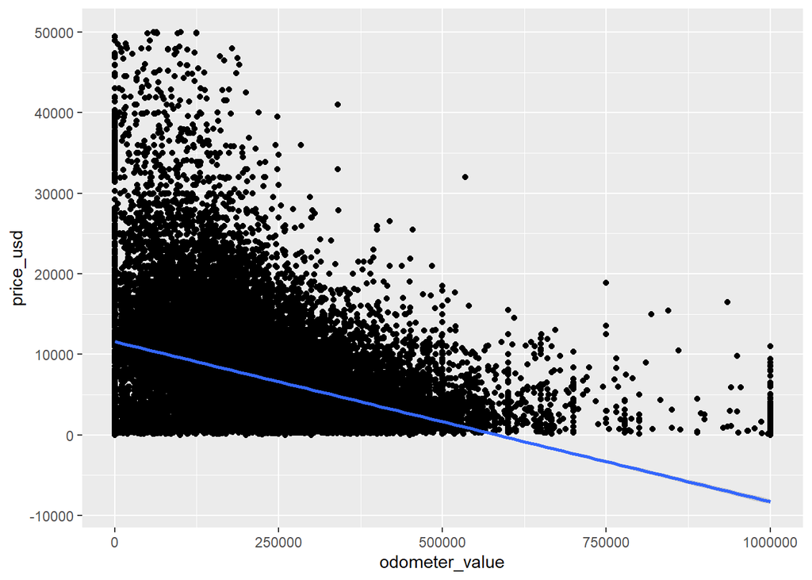

```r
summary(odometer_on_price)
```

```
##
## Call:
## lm(formula = price_usd ~ odometer_value, data = cars_edited)
##
## Residuals:
##    Min     1Q Median     3Q    Max
## -11577  -3514  -1122   2064  40854
##
## Coefficients:
##                  Estimate Std. Error t value Pr(>|t|)
## (Intercept)     1.158e+04  6.203e+01  186.65   <2e-16 ***
## odometer_value -1.986e-02  2.186e-04  -90.82   <2e-16 ***
## ---
## Signif. codes:  0 '***' 0.001 '**' 0.01 '*' 0.05 '.' 0.1 ' ' 1
##
## Residual standard error: 5830 on 38488 degrees of freedom
## Multiple R-squared:  0.1765, Adjusted R-squared:  0.1765
## F-statistic:  8248 on 1 and 38488 DF,  p-value: < 2.2e-16
```

```r
confint(odometer_on_price)
```

```
##                        2.5 %        97.5 %
## (Intercept)     1.145654e+04  1.169971e+04
## odometer_value -2.028451e-02 -1.942748e-02
```

```r
sigma(odometer_on_price)*100/mean(cars_edited$price_usd)
```

```
## [1] 87.89188
```

**Q:** Does the number of photos a vehicle has impact the selling price?

**Justification:** With our scatter plot graph we added a line of best fit for the data.

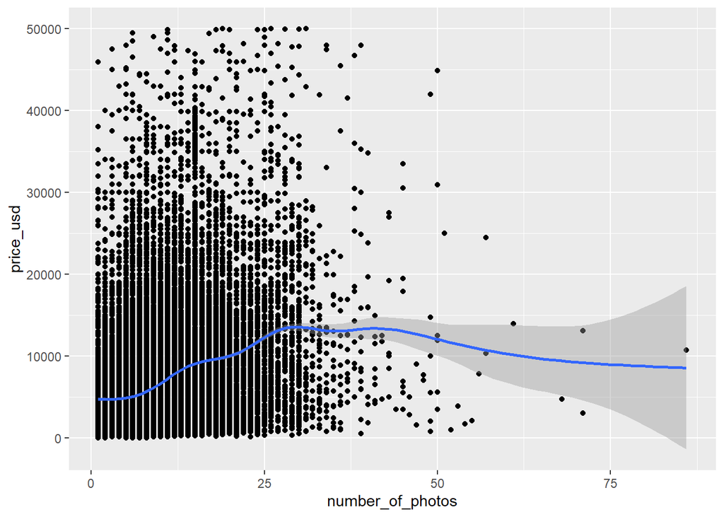

From the graph it seems like the more photos of a vehicle there are the higher the price will be. However, we can’t make that assumption based on just this graph, we need to use linear regression to confirm this.

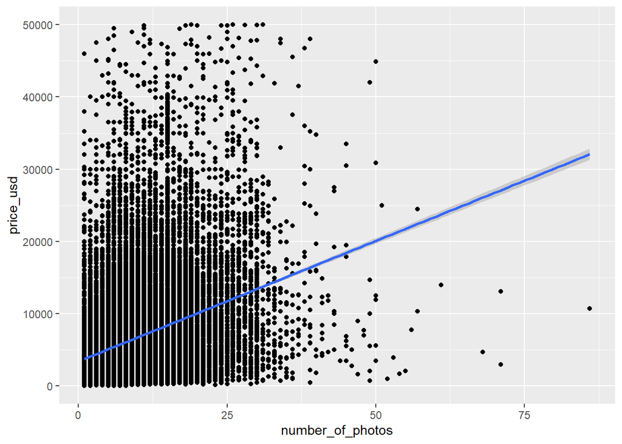

Now that we have the the linear regression line we need to make sure that the line fits the data with a high accuracy.

```r
summary(number_of_photos_on_price)
```

```
##
## Call:
## lm(formula = price_usd ~ number_of_photos, data = cars_edited)
##
## Residuals:
##    Min     1Q Median     3Q    Max
## -24082  -3884  -1585   2249  44082
##
## Coefficients:
##                  Estimate Std. Error t value Pr(>|t|)
## (Intercept)      3418.275     58.159   58.77   <2e-16 ***
## number_of_photos  333.297      5.098   65.38   <2e-16 ***
## ---
## Signif. codes:  0 '***' 0.001 '**' 0.01 '*' 0.05 '.' 0.1 ' ' 1
##
## Residual standard error: 6095 on 38488 degrees of freedom
## Multiple R-squared:  0.09997,    Adjusted R-squared:  0.09994
## F-statistic:  4275 on 1 and 38488 DF,  p-value: < 2.2e-16
```

```r
confint(number_of_photos_on_price)
```

```
##                     2.5 %    97.5 %
## (Intercept)      3304.283 3532.2680
## number_of_photos  323.305  343.2882
```

```r
sigma(number_of_photos_on_price)*100/mean(cars_edited$price_usd)
```

```
## [1] 91.88472
```

**Q:** Does the number of times a vehicle has been upped in the catalog to raise its position impact the selling price?

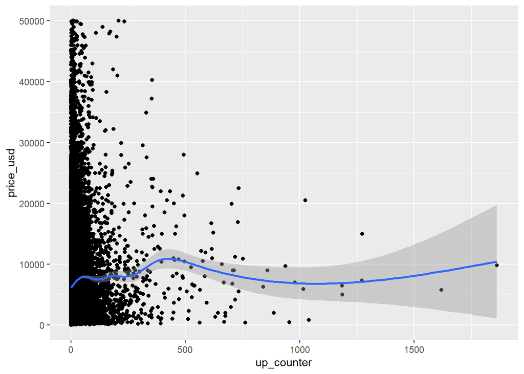

Again however, we can’t assume this to be true without checking the linear regression and getting the accuracy of that line.

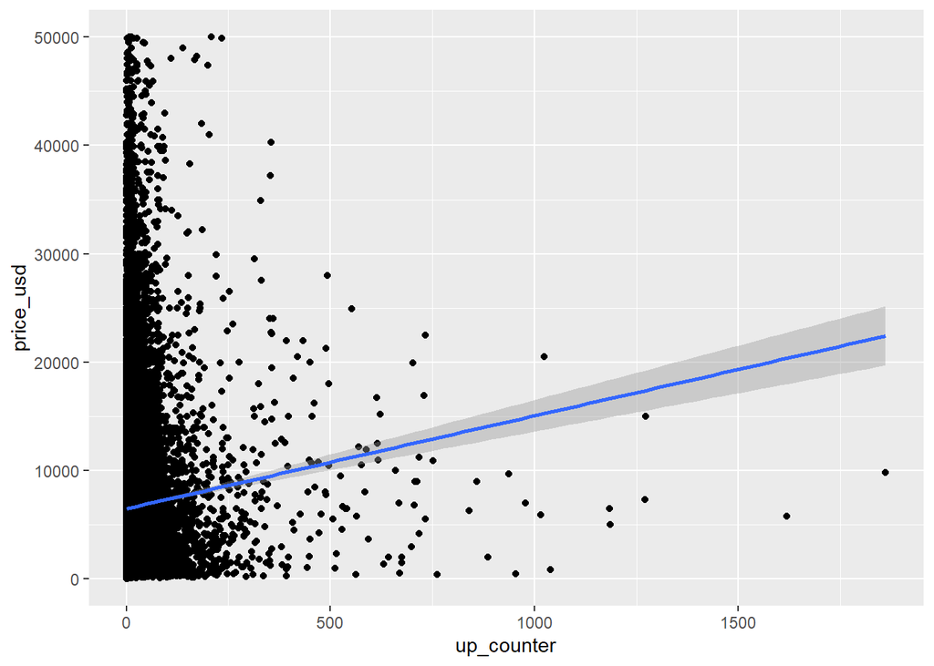

```r
up_counter_on_price <- lm (price_usd ~ up_counter, data = cars_edited)
summary(up_counter_on_price)
```

```
##
## Call:
## lm(formula = price_usd ~ up_counter, data = cars_edited)
##
## Residuals:
##    Min     1Q Median     3Q    Max
## -14558  -4502  -1852   2305  43438
##
## Coefficients:
##              Estimate Std. Error t value Pr(>|t|)
## (Intercept) 6493.0457    34.9345  185.86   <2e-16 ***
## up_counter     8.5694     0.7548   11.35   <2e-16 ***
## ---
## Signif. codes:  0 '***' 0.001 '**' 0.01 '*' 0.05 '.' 0.1 ' ' 1
##
## Residual standard error: 6413 on 38488 degrees of freedom
## Multiple R-squared:  0.003337,   Adjusted R-squared:  0.003311
## F-statistic: 128.9 on 1 and 38488 DF,  p-value: < 2.2e-16
```

```r
confint(up_counter_on_price)
```

```
##                   2.5 %     97.5 %
## (Intercept) 6424.573138 6561.51822
## up_counter     7.089888   10.04893
```

```r
sigma(up_counter_on_price)*100/mean(cars_edited$price_usd)
```

```
## [1] 96.69137
```

**Q:** Relationship between Engine Type and Body Type? What is the impact of Engine Type and Body Type on the selling price?

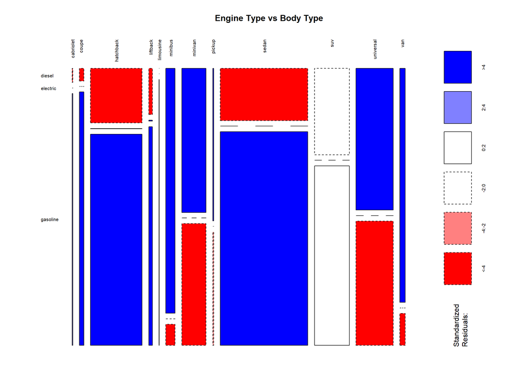

```r
#Aov3
body_engine_type_on_price.aov3 <- aov(price_usd ~ engine_type * body_type, data = cars_edited)
summary(body_engine_type_on_price.aov3)
```

```
##                          Df    Sum Sq   Mean Sq F value Pr(>F)
## engine_type               2 1.301e+10 6.503e+09  204.12 <2e-16 ***
## body_type                11 3.457e+11 3.142e+10  986.32 <2e-16 ***
## engine_type:body_type    11 4.280e+09 3.891e+08   12.21 <2e-16 ***
## Residuals             38465 1.225e+12 3.186e+07
## ---
## Signif. codes:  0 '***' 0.001 '**' 0.01 '*' 0.05 '.' 0.1 ' ' 1
```

```r
model.tables(body_engine_type_on_price.aov3, type="means", se = TRUE)
```

```
## Design is unbalanced - use se.contrast() for se's
```

```
## Tables of means
## Grand mean
##
## 6632.904
##
##  engine_type
##     diesel electric gasoline
##       7412    17465     6237
## rep  12869       10    25611
##
##  body_type
##     cabriolet coupe hatchback liftback limousine minibus minivan pickup sedan
##         11309  7798      4179     8023      8550    7780    5889  11470  5947
## rep        75   652      7644      551        12    1368    3608    129 12977
##       suv universal  van
##     13782      4786 6036
## rep  5162      5504  808
##
##  engine_type:body_type
##            body_type
## engine_type cabriolet coupe hatchback liftback limousine minibus minivan pickup
##    diesel    6350     10120  4120      8239               8638    6897   10704
##    rep          4        31  1571        96        0      1260    1956      74
##    electric                 15213     26475
##    rep          0         0     8         2        0         0       0       0
##    gasoline 11236      7325  4000      7713     8154      6462    5224   13153
##    rep         71       621  6065       453       12       108    1652      55
##            body_type
## engine_type sedan suv   universal van
##    diesel    6114 14959  5784      6942
##    rep       2554  1678  2934       711
##    electric
##    rep          0     0     0         0
##    gasoline  5701 13194  4141      4712
##    rep      10423  3484  2570        97
```

```r
#Tukey HSD
TukeyHSD(body_engine_type_on_price.aov3)
```

```
##   Tukey multiple comparisons of means
##     95% family-wise confidence level
##
## Fit: aov(formula = price_usd ~ engine_type * body_type, data = cars_edited)
##
## $engine_type
##                         diff        lwr       upr p adj
## electric-diesel    10052.532   5867.612 14237.452 1e-07
## gasoline-diesel    -1175.359  -1318.298 -1032.420 0e+00
## gasoline-electric -11227.891 -15412.002 -7043.779 0e+00
##
## $body_type
##                            diff         lwr        upr     p adj
## coupe-cabriolet     -3510.93890 -5760.05406 -1261.8237 0.0000218
## hatchback-cabriolet -7129.82230 -9270.19038 -4989.4542 0.0000000
## liftback-cabriolet  -3285.65559 -5555.93678 -1015.3744 0.0001423
## limousine-cabriolet -2758.76153 -8493.81258  2976.2895 0.9193030
## minibus-cabriolet   -3529.16912 -5716.72120 -1341.6170 0.0000088
## minivan-cabriolet   -5419.24172 -7571.21007 -3267.2734 0.0000000
## pickup-cabriolet      161.12611 -2517.35454  2839.6068 1.0000000
## sedan-cabriolet     -5362.19106 -7498.28165 -3226.1005 0.0000000
## suv-cabriolet        2473.04299   327.68105  4618.4049 0.0090611
## universal-cabriolet -6522.64572 -8667.05290 -4378.2385 0.0000000
## van-cabriolet       -5272.55651 -7499.16037 -3045.9527 0.0000000
## hatchback-coupe     -3618.88340 -4371.45730 -2866.3095 0.0000000
## liftback-coupe        225.28331  -842.12881  1292.6954 0.9999350
## limousine-coupe       752.17737 -4621.46222  6125.8170 0.9999991
## minibus-coupe         -18.23022  -896.05483   859.5944 1.0000000
## minivan-coupe       -1908.30282 -2693.26124 -1123.3444 0.0000000
## pickup-coupe         3672.06502  1894.58069  5449.5493 0.0000000
## sedan-coupe         -1851.25216 -2591.57298 -1110.9313 0.0000000
## suv-coupe            5983.98190  5217.32043  6750.6434 0.0000000
## universal-coupe     -3011.70681 -3775.69248 -2247.7211 0.0000000
## van-coupe           -1761.61761 -2732.67717  -790.5581 0.0000002
## liftback-hatchback   3844.16671  3030.51741  4657.8160 0.0000000
## limousine-hatchback  4371.06077  -957.97845  9700.1000 0.2358264
## minibus-hatchback    3600.65318  3059.14363  4142.1627 0.0000000
## minivan-hatchback    1710.58058  1338.00004  2083.1611 0.0000000
## pickup-hatchback     7290.94841  5653.23443  8928.6624 0.0000000
## sedan-hatchback      1767.63124  1501.67738  2033.5851 0.0000000
```

[output cut: 1288 more lines]

```
## electric:universal-diesel:universal          NA
## gasoline:universal-diesel:universal   0.0000000
## diesel:van-diesel:universal           0.0005282
## electric:van-diesel:universal                NA
## gasoline:van-diesel:universal         0.9980468
## gasoline:universal-electric:universal        NA
## diesel:van-electric:universal                NA
## electric:van-electric:universal              NA
## gasoline:van-electric:universal              NA
## diesel:van-gasoline:universal         0.0000000
## electric:van-gasoline:universal              NA
## gasoline:van-gasoline:universal       1.0000000
## electric:van-diesel:van                      NA
## gasoline:van-diesel:van               0.0926816
## gasoline:van-electric:van                    NA
```

**Q:** What is the most popular model and whether we can conclude that the popularity of a model has a direct impact on the price of a vehicle?

**Q:** What is the most popular model and whether we can conclude that the popularity of a model has a direct impact on the price of a vehicle?

**Justification:** With the nature of this question we need to organize some data before we can graph it.

```r
models_sorted <- group_by(cars_edited, model_name)
#Find popularity of vehicles
models_counted <- cars_edited %>% count(model_name) %>% arrange(desc(n))

#Find average price for each model
models_sorted_averages <- summarise(models_sorted, average_price_usd = mean(price_usd))

#Get the count of each model
models_sorted_avg_with_cnt <- models_sorted_averages %>% mutate(counts = count(cars_edited, model_name) %>% dplyr::select(2))
models_sorted_avg_with_cnt$counts <- as.numeric(unlist(models_sorted_avg_with_cnt$counts))
```

Now that we have the data in a way where the models of each of the cars has a count, with a price we can graph it.

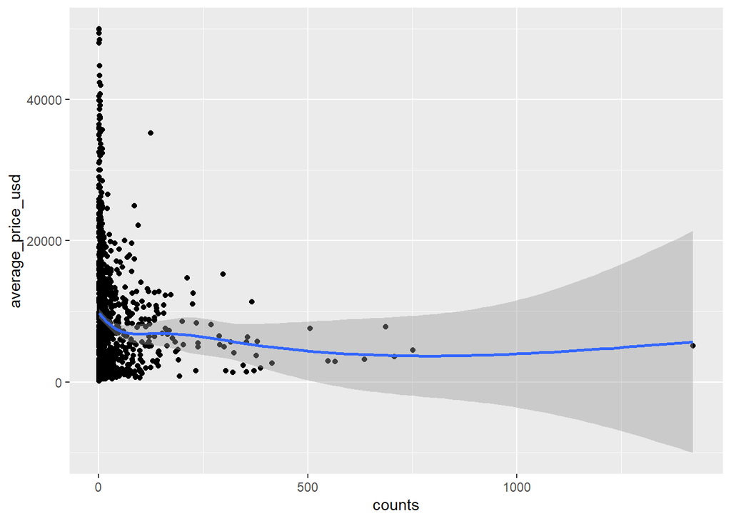

From this scatter plot that has a line of best fit, it is kind of hard to tell what the result will be. Now we can run linear regression on this to be sure of what relationship there is.

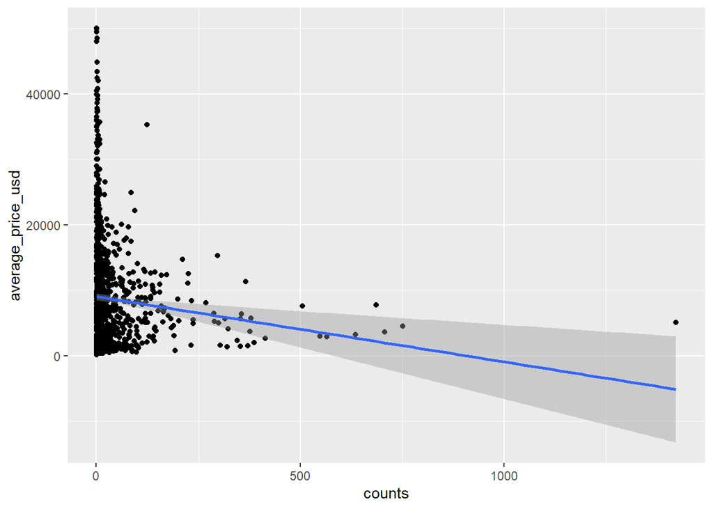

Next we need to be sure of the accuracy of the linear regression line.

```r
modelPricePerCount <- lm (average_price_usd ~ counts, data = models_sorted_avg_with_cnt)
summary(modelPricePerCount)
```

```
##
## Call:
## lm(formula = average_price_usd ~ counts, data = models_sorted_avg_with_cnt)
##
## Residuals:
##    Min     1Q Median     3Q    Max
##  -8887  -6096  -2217   2863  40964
##
## Coefficients:
##             Estimate Std. Error t value Pr(>|t|)
## (Intercept) 9045.783    271.631   33.30  < 2e-16 ***
## counts        -9.966      2.975   -3.35 0.000836 ***
## ---
## Signif. codes:  0 '***' 0.001 '**' 0.01 '*' 0.05 '.' 0.1 ' ' 1
##
## Residual standard error: 8412 on 1116 degrees of freedom
## Multiple R-squared:  0.009954,   Adjusted R-squared:  0.009067
## F-statistic: 11.22 on 1 and 1116 DF,  p-value: 0.0008361
```

```r
confint(modelPricePerCount)
```

```
##                  2.5 %      97.5 %
## (Intercept) 8512.81827 9578.747230
## counts       -15.80376   -4.128411
```

```r
sigma(modelPricePerCount)*100/mean(models_sorted_avg_with_cnt$average_price_usd)
```

```
## [1] 96.65859
```

Because of this analysis we can conclude that **the popularity of a vehicle does have an impact on the average_price of a vehicle.**

**Q:** What is the average age of each vehicle manufacturer and whether the manufacturer changes how the production year impacts the selling price?

**Justification:** With this question we decided to use a scatter plot and color all the points in the scatter plot with a color corresponding to a different manufacturer.

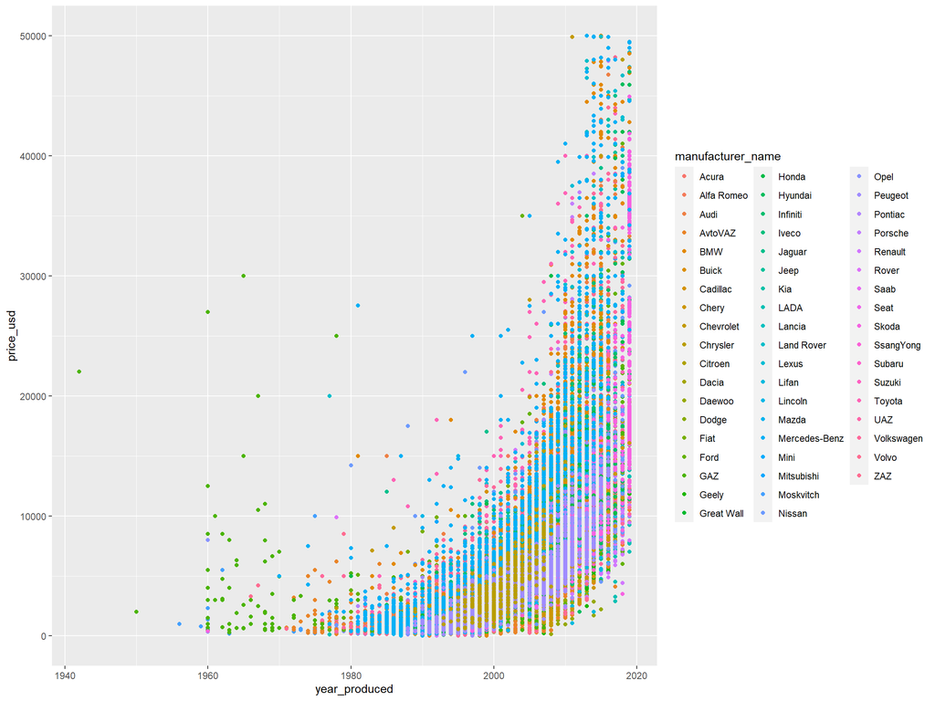

Again we can’t look at just the graph and call it a day, we need to confirm the results using a different method.

```r
manufacturer_price <- aov(price_usd ~ manufacturer_name * year_produced, data = cars_edited)
summary(manufacturer_price)
```

```
##                                    Df    Sum Sq   Mean Sq F value Pr(>F)
## manufacturer_name                  54 2.917e+11 5.402e+09   428.4 <2e-16 ***
## year_produced                       1 6.854e+11 6.854e+11 54355.5 <2e-16 ***
## manufacturer_name:year_produced    54 1.273e+11 2.357e+09   186.9 <2e-16 ***
## Residuals                       38380 4.840e+11 1.261e+07
## ---
## Signif. codes:  0 '***' 0.001 '**' 0.01 '*' 0.05 '.' 0.1 ' ' 1
```

With these results we can confirm our original assumption. **The manufacturer does change how the production year affects the selling price.**